# Week 1 - Decomposition of Time Series

Petra Tomanová

2023-09-20

This markdown document is intended for the **Econometric Modelling** seminar. Its purpose is to demonstrate practical examples and provide exercises on the topic of **Decomposition of Time Series**. The outline includes:

- Spurious regression
- Trends in time series
- Seasonality in time series
- Moving averages

## Settings and libraries

Let’s begin by configuring the settings. For the sake of convenience, instruct R to refrain from using “scientific notation” when displaying both large and small numbers.

```r
options(scipen=10) # Print 0.00513 instead of 5.13e-03.
```

It is time to import the libraries that we will be using for our work.

```r
library(ggplot2)    # Data visualization
library(reshape2)   # Manipulate the data from the 'wide' to the 'long' format
library(dplyr)      # Grammar of data manipulation
library(stargazer)  # Well-formatted regression tables
library(cowsay)     # The most important package of all time
```

## Spurious regression and trends in time series

Let’s discuss one of the challenges we will encounter when working with time series data: **spurious regression**. This does not imply that spurious regression is not a concern in cross-sectional analysis; rather, it is more frequently encountered in time series analysis. To illustrate the concept of spurious regression or correlation, let’s take a look at some amusing examples.

https://www.tylervigen.com/spurious-correlations

```
##
##  -----
## So, does a correlation of 94.71% mean that eating cheese somehow leads to people getting stuck in their bedsheets and dying?! Oh my gosh, I'm stopping milk production for cheese right now! This is a murder scene! But don't blame me; see what wild game in the Czechia does!
##  ------
##     \   ^__^
##      \  (oo)\ ________
##         (__)\         )\ /\
##              ||------w|
##              ||      ||
```

### Example 1: Probability of prepayments and wild game

This example is based on a real story from a Czech bank where I worked as a consultant. There was a humorous incident where a modeler attempted to predict the probability of default on leases by using brute force regression on all variables in the database against the dependent variable. Surprisingly, one of the strongest predictors turned out to be a Japanese interest rate.

When I was building a model for predicting prepayments, I decided to humorously replicate the approach by regressing all available variables against my dependent variable. The unexpected result was that the number of wild game in Czechia emerged as a significant predictor!

```r
data <- read.csv("game.csv")
head(data)
```

```
##         date   game prepayment
## 1 31/01/2008 123000  0.1272374
## 2 29/02/2008 123050  0.1258574
## 3 31/03/2008 123080  0.1255050
## 4 30/04/2008 123075  0.1238306
## 5 31/05/2008 123100  0.1227917
## 6 30/06/2008 123250  0.1219033
```

```r
data$date <- as.POSIXct(data$date, format = "%d/%m/%Y")
str(data)
```

```
## 'data.frame':    104 obs. of  3 variables:
##  $ date      : POSIXct, format: "2008-01-31" "2008-02-29" ...
##  $ game      : num  123000 123050 123080 123075 123100 ...
##  $ prepayment: num  0.127 0.126 0.126 0.124 0.123 ...
```

We can observe that, contrary to common intuition, game is a significant variable in the model.

```r
m1 <- lm(prepayment ~ game, data = data, subset = 1:80)
summary(m1)
```

```
##
## Call:
## lm(formula = prepayment ~ game, data = data, subset = 1:80)
##
## Residuals:
##        Min         1Q     Median         3Q        Max
## -0.0236831 -0.0029084  0.0003514  0.0066428  0.0166660
##
## Coefficients:
##                  Estimate    Std. Error t value Pr(>|t|)
## (Intercept)  0.7362489926  0.0145040608   50.76   <2e-16 ***
## game        -0.0000050399  0.0000001271  -39.66   <2e-16 ***
## ---
## Signif. codes:  0 '***' 0.001 '**' 0.01 '*' 0.05 '.' 0.1 ' ' 1
##
## Residual standard error: 0.009817 on 78 degrees of freedom
## Multiple R-squared:  0.9528, Adjusted R-squared:  0.9521
## F-statistic:  1573 on 1 and 78 DF,  p-value: < 2.2e-16
```

Let us calculate fitted and predicted values for the last 24 observations.

```r
data$prediction <- predict(m1, data)
data$fit <- c(predict(m1),rep(NA,24))
```

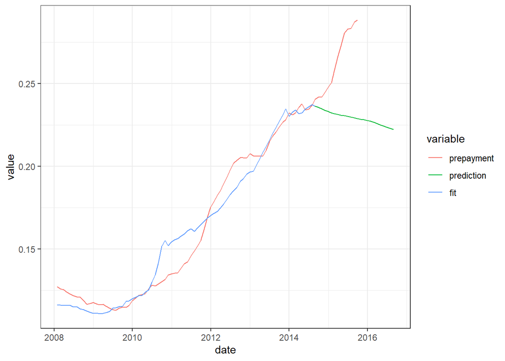

```
##
##  -----
## I told you that wild game is dangerous! Domestic animals are much cooler :)
##  ------
##     \   ^__^
##      \  (oo)\ ________
##         (__)\         )\ /\
##              ||------w|
##              ||      ||
```

```r
dataS <- data[complete.cases(data),]
m1 <- lm(prepayment ~ game, data = dataS)
summary(m1)
```

```
##
## Call:
## lm(formula = prepayment ~ game, data = dataS)
##
## Residuals:
##        Min         1Q     Median         3Q        Max
## -0.0236831 -0.0029084  0.0003514  0.0066428  0.0166660
##
## Coefficients:
##                  Estimate    Std. Error t value Pr(>|t|)
## (Intercept)  0.7362489926  0.0145040608   50.76   <2e-16 ***
## game        -0.0000050399  0.0000001271  -39.66   <2e-16 ***
## ---
## Signif. codes:  0 '***' 0.001 '**' 0.01 '*' 0.05 '.' 0.1 ' ' 1
##
## Residual standard error: 0.009817 on 78 degrees of freedom
## Multiple R-squared:  0.9528, Adjusted R-squared:  0.9521
## F-statistic:  1573 on 1 and 78 DF,  p-value: < 2.2e-16
```

```r
dataS$trend <- 1:nrow(dataS)
head(dataS)
```

```
##         date   game prepayment prediction       fit trend
## 1 2008-01-31 123000  0.1272374  0.1163402 0.1163402     1
## 2 2008-02-29 123050  0.1258574  0.1160882 0.1160882     2
## 3 2008-03-31 123080  0.1255050  0.1159370 0.1159370     3
## 4 2008-04-30 123075  0.1238306  0.1159622 0.1159622     4
## 5 2008-05-31 123100  0.1227917  0.1158362 0.1158362     5
## 6 2008-06-30 123250  0.1219033  0.1150802 0.1150802     6
```

```r
m2 <- lm(prepayment ~ trend, data = dataS) # Regress the variable on time.
dataS$fit2 <- predict(m2)
summary(m2)
```

```
##
## Call:
## lm(formula = prepayment ~ trend, data = dataS)
##
## Residuals:
##       Min        1Q    Median        3Q       Max
## -0.022422 -0.014224  0.002928  0.009417  0.036741
##
## Coefficients:
##               Estimate Std. Error t value Pr(>|t|)
## (Intercept) 0.08866961 0.00330723   26.81   <2e-16 ***
## trend       0.00182680 0.00007094   25.75   <2e-16 ***
## ---
## Signif. codes:  0 '***' 0.001 '**' 0.01 '*' 0.05 '.' 0.1 ' ' 1
##
## Residual standard error: 0.01465 on 78 degrees of freedom
## Multiple R-squared:  0.8948, Adjusted R-squared:  0.8934
## F-statistic: 663.2 on 1 and 78 DF,  p-value: < 2.2e-16
```

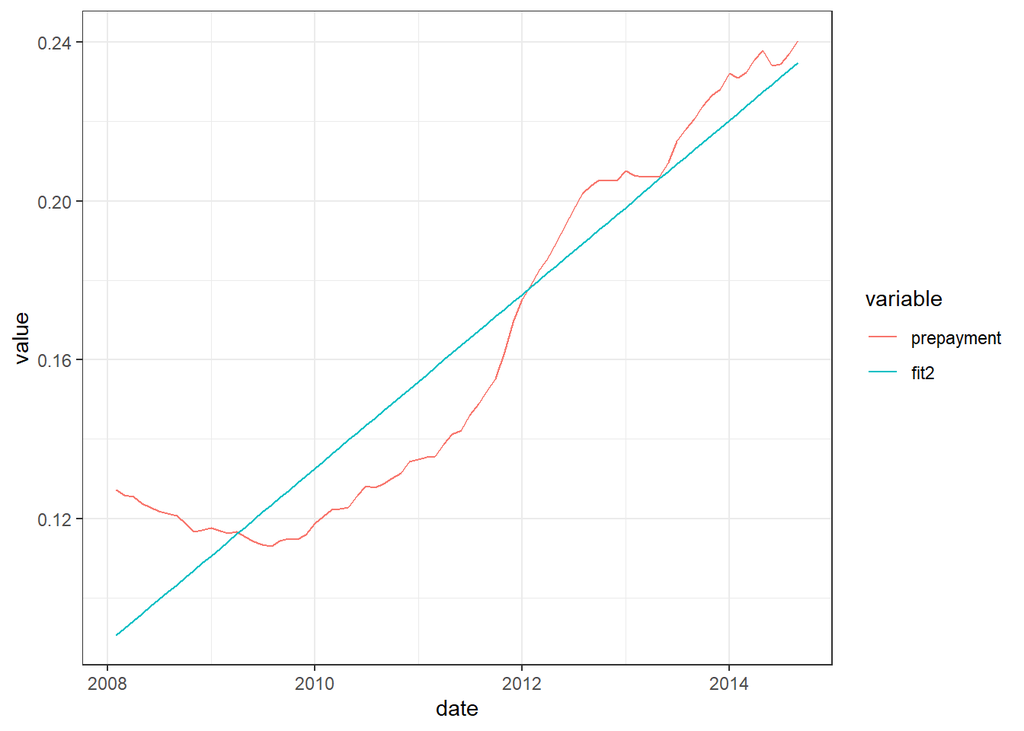

```r
dataS$prep.detrended <- m2$residuals # Save residuals - the detrended variable.
```

```r
dataS$game.detrended <- lm(game ~ trend, data = dataS)$residuals
```

Now, run the regression with detrended variables.

```r
m3 <- lm(prep.detrended ~ game.detrended, data = dataS)
summary(m3)
```

```
##
## Call:
## lm(formula = prep.detrended ~ game.detrended, data = dataS)
##
## Residuals:
##       Min        1Q    Median        3Q       Max
## -0.024310 -0.002904  0.001319  0.005615  0.017348
##
## Coefficients:
##                  Estimate Std. Error t value Pr(>|t|)
## (Intercept)    -2.903e-18  1.089e-03   0.000        1
## game.detrended -5.665e-06  5.706e-07  -9.928 1.74e-15 ***
## ---
## Signif. codes:  0 '***' 0.001 '**' 0.01 '*' 0.05 '.' 0.1 ' ' 1
##
## Residual standard error: 0.009739 on 78 degrees of freedom
## Multiple R-squared:  0.5582, Adjusted R-squared:  0.5526
## F-statistic: 98.56 on 1 and 78 DF,  p-value: 1.736e-15
```

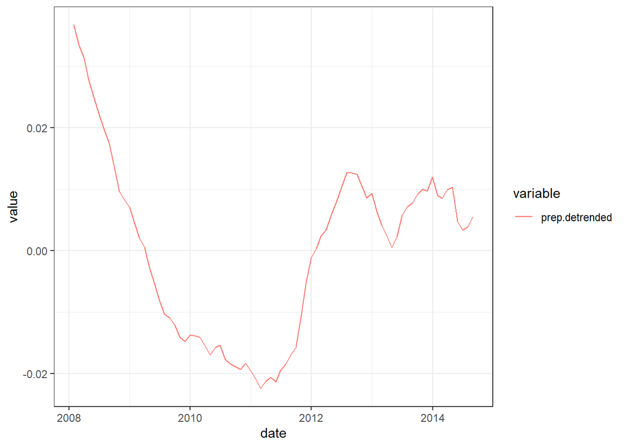

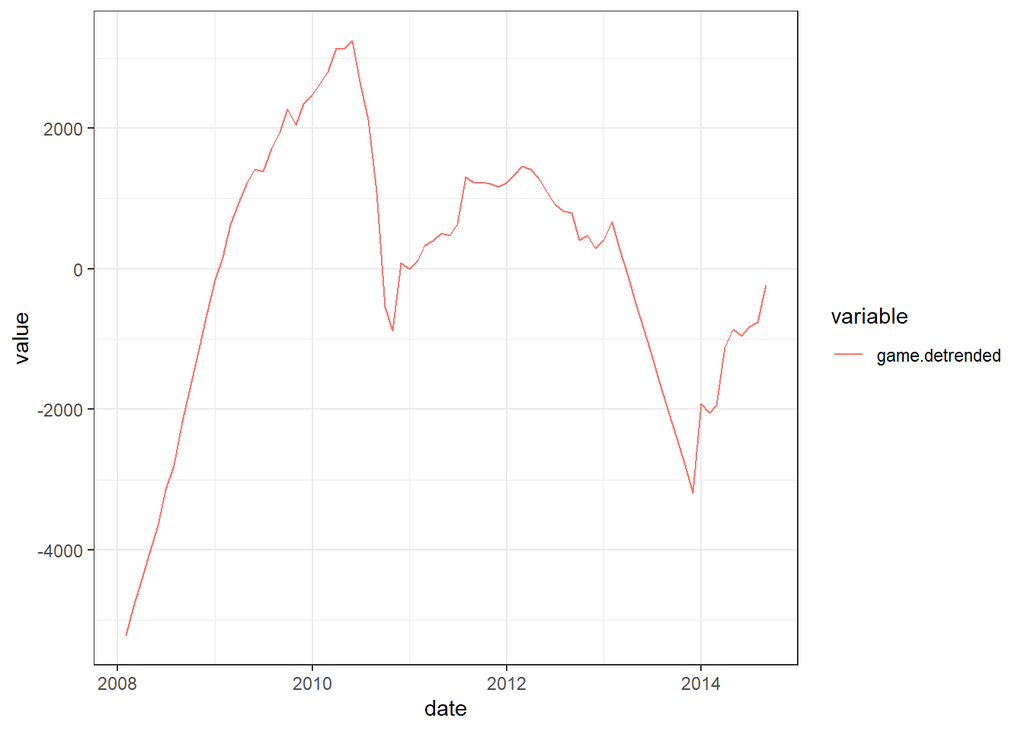

The same effect of game is estimated, if we use the original variables and add time as another regressor:

```r
m4 <- lm(prepayment ~ game + trend, data = dataS)
summary(m4)
```

```
##
## Call:
## lm(formula = prepayment ~ game + trend, data = dataS)
##
## Residuals:
##       Min        1Q    Median        3Q       Max
## -0.024310 -0.002904  0.001319  0.005615  0.017348
##
## Coefficients:
##                  Estimate    Std. Error t value Pr(>|t|)
## (Intercept)  0.8171081205  0.0738810685  11.060  < 2e-16 ***
## game        -0.0000056651  0.0000005743  -9.864 2.63e-15 ***
## trend       -0.0002397503  0.0002148109  -1.116    0.268
## ---
## Signif. codes:  0 '***' 0.001 '**' 0.01 '*' 0.05 '.' 0.1 ' ' 1
##
## Residual standard error: 0.009802 on 77 degrees of freedom
## Multiple R-squared:  0.9535, Adjusted R-squared:  0.9523
## F-statistic: 789.6 on 2 and 77 DF,  p-value: < 2.2e-16
```

The estimated effect of game is identical, and the standard errors are nearly identical; they only differ because R used different degrees of freedom in the calculation (one more coefficient is estimated in **m4**).

For an easy comparison of all models, we can produce a regression table with all models in it, e.g. using the stargazer function from a package of the same name.

```r
stargazer(m1, m3, m4, type="text", digits=6)
```

```
##
## =====================================================================================================
##                                                    Dependent variable:
##                     ---------------------------------------------------------------------------------
##                              prepayment               prep.detrended               prepayment
##                                 (1)                         (2)                       (3)
## -----------------------------------------------------------------------------------------------------
## game                        -0.000005***                                          -0.000006***
##                             (0.0000001)                                            (0.000001)
##
## game.detrended                                         -0.000006***
##                                                         (0.000001)
##
## trend                                                                              -0.000240
##                                                                                    (0.000215)
##
## Constant                    0.736249***                  -0.000000                0.817108***
##                              (0.014504)                 (0.001089)                 (0.073881)
##
## -----------------------------------------------------------------------------------------------------
## Observations                     80                         80                         80
## R2                            0.952755                   0.558231                   0.953508
## Adjusted R2                   0.952150                   0.552567                   0.952300
## Residual Std. Error      0.009817 (df = 78)         0.009739 (df = 78)         0.009802 (df = 77)
## F Statistic         1,572.983000*** (df = 1; 78) 98.562780*** (df = 1; 78) 789.591700*** (df = 2; 77)
## =====================================================================================================
## Note:                                                                     *p<0.1; **p<0.05; ***p<0.01
```

In practice, rather than detrending all variables, it’s easier to add time among explanatory variables. The only drawback is that the R-squared reported after this regression is largely unusable. In our last model, it is 0.95; however, most of the explained variation in prepayments can be attributed to time, which is something we do not like to see included in R-squared. What we normally do is re-run te same regression, but with a detrended dependent variable. This means that we only have to detrend the dependent variable and leave all other variables as they are. (Here, we only have one explanatory variable, of course.)

```r
m5 <- lm(prep.detrended ~ game + trend, data = dataS) # Same results for game, better R-squared.
stargazer(m3, m4, m5, type="text", digits=6) # Only last three models (not to exceed page width)
```

```
##
## ==================================================================================================
##                                                  Dependent variable:
##                     ------------------------------------------------------------------------------
##                          prep.detrended               prepayment              prep.detrended
##                                (1)                       (2)                        (3)
## --------------------------------------------------------------------------------------------------
## game.detrended            -0.000006***
##                            (0.000001)
##
## game                                                 -0.000006***              -0.000006***
##                                                       (0.000001)                (0.000001)
##
## trend                                                 -0.000240                -0.002067***
##                                                       (0.000215)                (0.000215)
##
## Constant                    -0.000000                0.817108***                0.728439***
##                            (0.001089)                 (0.073881)                (0.073881)
##
## --------------------------------------------------------------------------------------------------
## Observations                   80                         80                        80
## R2                          0.558231                   0.953508                  0.558231
## Adjusted R2                 0.552567                   0.952300                  0.546756
## Residual Std. Error    0.009739 (df = 78)         0.009802 (df = 77)        0.009802 (df = 77)
## F Statistic         98.562780*** (df = 1; 78) 789.591700*** (df = 2; 77) 48.649580*** (df = 2; 77)
## ==================================================================================================
## Note:                                                                  *p<0.1; **p<0.05; ***p<0.01
```

**Results of linear regression with differenced variables**

Alternatively, we could also remove the linear trend by differencing the time series. However, the regression model then has a different interpretation as we are modeling a different variable. We also have one less observation.

```r
m6 <- lm (diff(prepayment) ~ diff(game), data = dataS)
summary (m6)
```

```
##
## Call:
## lm(formula = diff(prepayment) ~ diff(game), data = dataS)
##
## Residuals:
##        Min         1Q     Median         3Q        Max
## -0.0051897 -0.0016772 -0.0001972  0.0015684  0.0059395
##
## Coefficients:
##                  Estimate    Std. Error t value  Pr(>|t|)
## (Intercept)  0.0012273114  0.0002973923   4.127 0.0000923 ***
## diff(game)  -0.0000006780  0.0000005772  -1.175     0.244
## ---
## Signif. codes:  0 '***' 0.001 '**' 0.01 '*' 0.05 '.' 0.1 ' ' 1
##
## Residual standard error: 0.002143 on 77 degrees of freedom
## Multiple R-squared:  0.01761,    Adjusted R-squared:  0.004849
## F-statistic:  1.38 on 1 and 77 DF,  p-value: 0.2437
```

### Example 2: GDP in the U.S. and Norwegian salmon production

```
##
##  -----
## Let's explore the spurious regression one more time. Let's see how the fishes affect our lives... or are the results just lies? Something is fishy about these fishes... Now it is up to you to find out! Don't worry; I will guide your steps. Let's start with the data.
##  ------
##     \   ^__^
##      \  (oo)\ ________
##         (__)\         )\ /\
##              ||------w|
##              ||      ||
```

The data in salmon.gdt contain two annual time series (1983–2011) * annual salmon production in Norway * GDP in the U.S. (bln. of 2005 dollars)

Do you think that there is a **strong causal relationship**?

```r
data2 <- read.csv("http://nb.vse.cz/~zouharj/econ/salmon.csv")
head(data2)
```

```
##    obs  salmon    gdp time
## 1 1983 1244143 6130.9    1
## 2 1984 1323451 6571.5    2
## 3 1985 1239021 6843.4    3
## 4 1986 1291301 7080.5    4
## 5 1987 1013571 7307.0    5
## 6 1988  841587 7607.4    6
```

```
##
##  -----
## As with all time series, it is a good idea to view the plots first.
##  ------
##     \   ^__^
##      \  (oo)\ ________
##         (__)\         )\ /\
##              ||------w|
##              ||      ||
```

```
##
##  -----
## Estimate a naive regression, ignoring trends and other potential factors, and visualize your results.
##  ------
##     \   ^__^
##      \  (oo)\ ________
##         (__)\         )\ /\
##              ||------w|
##              ||      ||
```

```
##
##  -----
## Now, detrend both time series by calculating the residuals from a simple regression of each variable on time. Then, estimate the model using the detrended variables.
##  ------
##     \   ^__^
##      \  (oo)\ ________
##         (__)\         )\ /\
##              ||------w|
##              ||      ||
```

```
##
##  -----
## Include time as an additional regressor in the naive regression.
##  ------
##     \   ^__^
##      \  (oo)\ ________
##         (__)\         )\ /\
##              ||------w|
##              ||      ||
```

```
##
##  -----
## Use the stargazer package to compare all models.
##  ------
##     \   ^__^
##      \  (oo)\ ________
##         (__)\         )\ /\
##              ||------w|
##              ||      ||
```

## Seasonality in time series

### Example 3: Durable goods

We’ll import the data in durgoods.csv. The dataset contains quarterly data on appliance sales (in thousands of appliances) from 1978:1 to 1985:4.

```r
data3 <- read.csv("http://nb.vse.cz/~zouharj/econ/durgoods.csv")
data3$time <- 1:nrow(data3)
head(data3)
```

```
##   dish frig wash time
## 1  841 1317 1271    1
## 2  957 1615 1295    2
## 3  999 1662 1313    3
## 4  960 1295 1150    4
## 5  894 1271 1289    5
## 6  851 1555 1245    6
```

First we have to create the time trend variable and seasonal dummies. Note the syntax for seasonal dummies.

```r
data3$time <- seq(from=1978, to=1985.75, by=0.25)
data3$quarter <- as.factor(rep(1:4, length.out=nrow(data3)))
head(data3, n=10)
```

```
##    dish frig wash    time quarter
## 1   841 1317 1271 1978.00       1
## 2   957 1615 1295 1978.25       2
## 3   999 1662 1313 1978.50       3
## 4   960 1295 1150 1978.75       4
## 5   894 1271 1289 1979.00       1
## 6   851 1555 1245 1979.25       2
## 7   863 1639 1270 1979.50       3
## 8   878 1238 1103 1979.75       4
## 9   792 1277 1273 1980.00       1
## 10  589 1258 1031 1980.25       2
```

Are refrigerator sales seasonal?

```
##
##  -----
## Let’s find out whether refrigerator sales exhibit a significant seasonal pattern.
##  ------
##     \   ^__^
##      \  (oo)\ ________
##         (__)\         )\ /\
##              ||------w|
##              ||      ||
```

```r
m7 <- lm(frig ~ time + quarter, data=data3)
data3$fitFrig <- m7$fitted.values
summary(m7)
```

```
##
## Call:
## lm(formula = frig ~ time + quarter, data = data3)
##
## Residuals:
##     Min      1Q  Median      3Q     Max
## -304.17 -135.95   57.85  125.14  214.38
##
## Coefficients:
##               Estimate Std. Error t value Pr(>|t|)
## (Intercept) -12347.612  26286.445  -0.470 0.642317
## time             6.848     13.266   0.516 0.609898
## quarter2       243.663     86.037   2.832 0.008635 **
## quarter3       344.201     86.228   3.992 0.000452 ***
## quarter4       -67.261     86.547  -0.777 0.443817
## ---
## Signif. codes:  0 '***' 0.001 '**' 0.01 '*' 0.05 '.' 0.1 ' ' 1
##
## Residual standard error: 171.9 on 27 degrees of freedom
## Multiple R-squared:  0.5364, Adjusted R-squared:  0.4677
## F-statistic: 7.809 on 4 and 27 DF,  p-value: 0.0002566
```

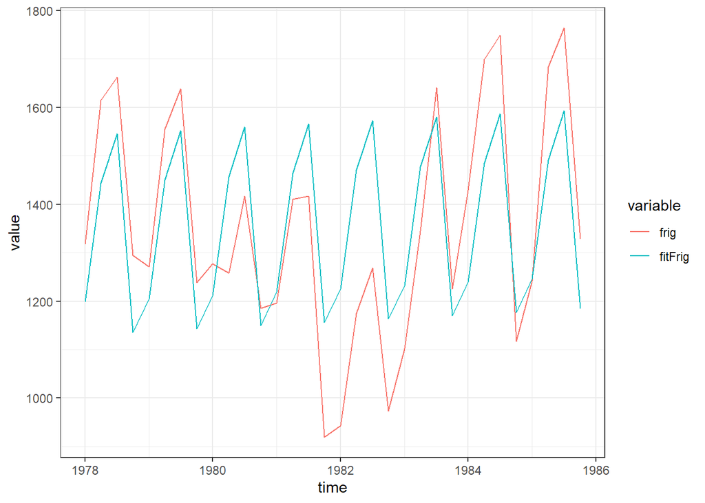

Since quarter is a categorical variable, we should use an F-test for joint significance of the three dummies.

```r
anova(m7, lm(frig ~ time, data = data3)) # F-test using the anova function.
```

```
## Analysis of Variance Table
##
## Model 1: frig ~ time + quarter
## Model 2: frig ~ time
##   Res.Df     RSS Df Sum of Sq      F    Pr(>F)
## 1     27  798264
## 2     30 1715109 -3   -916845 10.337 0.0001052 ***
## ---
## Signif. codes:  0 '***' 0.001 '**' 0.01 '*' 0.05 '.' 0.1 ' ' 1
```

Conclusion: seasonal pattern is significant.

Are dishwasher sales seasonal?

```
##
##  -----
## Let’s do the same for the dish variable.
##  ------
##     \   ^__^
##      \  (oo)\ ________
##         (__)\         )\ /\
##              ||------w|
##              ||      ||
```

```r
m8 <- lm(dish ~ time + quarter, data=data3)
data3$fitDish <- m8$fitted.values
summary(m8)
```

```
##
## Call:
## lm(formula = dish ~ time + quarter, data = data3)
##
## Residuals:
##     Min      1Q  Median      3Q     Max
## -270.27 -113.63   64.41  110.44  199.83
##
## Coefficients:
##              Estimate Std. Error t value Pr(>|t|)
## (Intercept)  5300.982  23817.135   0.223    0.826
## time           -2.298     12.020  -0.191    0.850
## quarter2        8.824     77.955   0.113    0.911
## quarter3       44.024     78.128   0.563    0.578
## quarter4       51.598     78.417   0.658    0.516
##
## Residual standard error: 155.8 on 27 degrees of freedom
## Multiple R-squared:  0.0233, Adjusted R-squared:  -0.1214
## F-statistic: 0.161 on 4 and 27 DF,  p-value: 0.9562
```

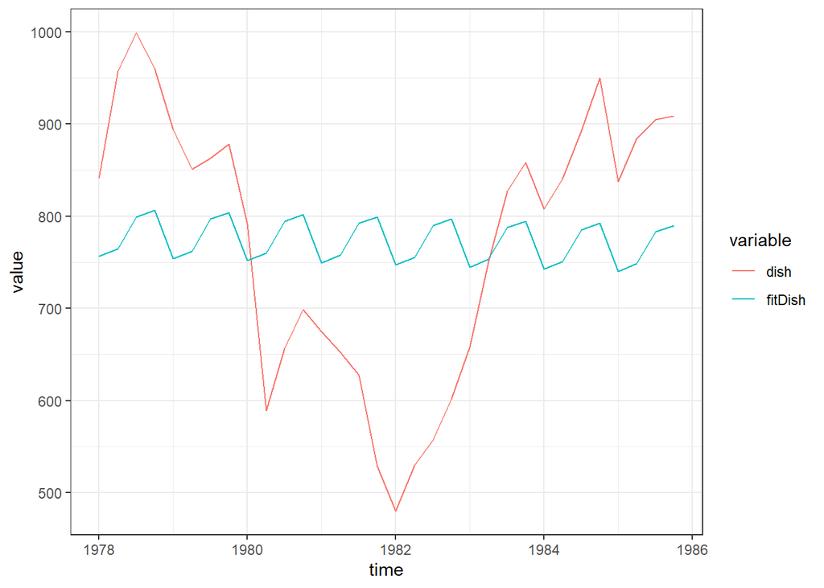

```r
anova(m8, lm(dish ~ time, data = data3)) # F-test using the anova function.
```

```
## Analysis of Variance Table
##
## Model 1: dish ~ time + quarter
## Model 2: dish ~ time
##   Res.Df    RSS Df Sum of Sq      F Pr(>F)
## 1     27 655332
## 2     30 670729 -3    -15397 0.2115 0.8876
```

Conclusion: seasonal pattern is not significant.

## Moving averages

Now, we will demonstrate moving average techniques using annual flow measurements of the Nile River at Aswan (formerly Assuan) from 1871 to 1970, in 10^8 cubic meters.

```r
data("Nile")
n <- length(Nile)
data4 <- data.frame(t = 1:n, year = 1871:1970, Nile = as.vector(Nile))
head(data4)
```

```
##   t year Nile
## 1 1 1871 1120
## 2 2 1872 1160
## 3 3 1873  963
## 4 4 1874 1210
## 5 5 1875 1160
## 6 6 1876 1160
```

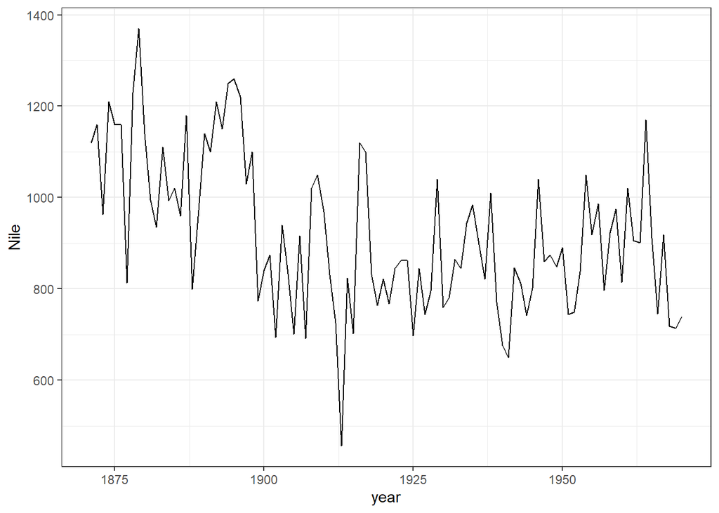

```r
ggplot(data4, aes(x = year,  y = Nile)) +
  geom_line() +
  theme_bw()
```

**Simple Centered Moving Averages**

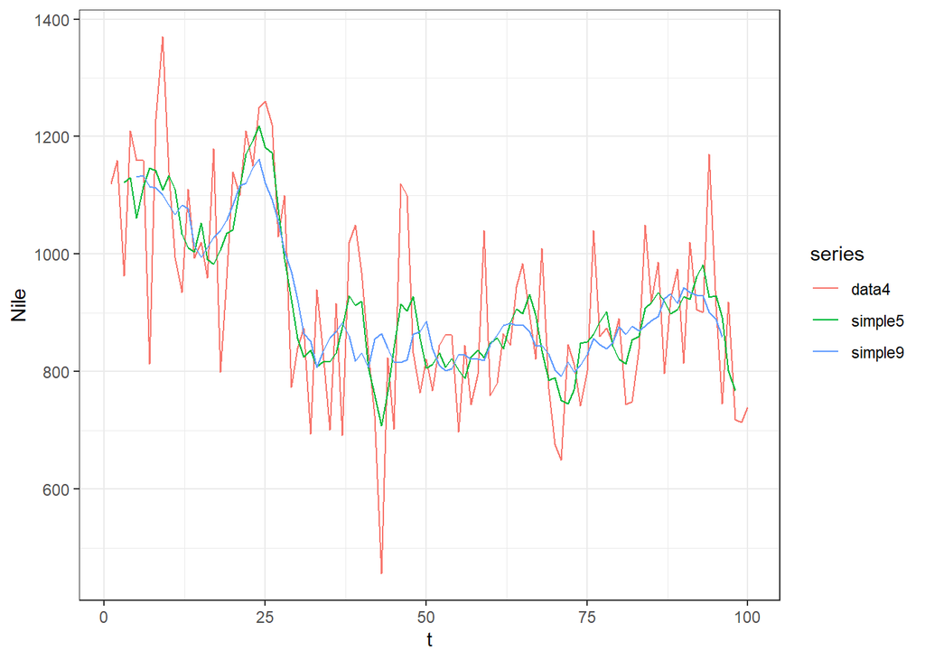

```
##
##  -----
## Try manually calculating the series above.
##  ------
##     \   ^__^
##      \  (oo)\ ________
##         (__)\         )\ /\
##              ||------w|
##              ||      ||
```

```r
data_simple <- data4 %>%
  mutate(series = "data4") %>%
  add_row(t = 1:n, Nile = stats::filter(data4$Nile, filter = rep(1 / 5, 5), sides = 2), series = "simple5") %>%
  add_row(t = 1:n, Nile = stats::filter(data4$Nile, filter = rep(1 / 9, 9), sides = 2), series = "simple9")

ggplot(data_simple, aes(t, Nile, group_by = series, color = series)) +
  geom_line() +
  theme_bw()
```

**Exponential Trailing Moving Average**

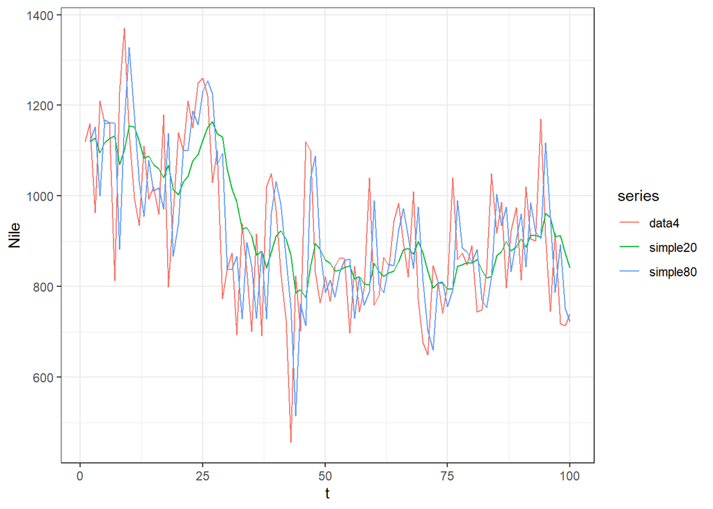

```r
data_exp <- data4 %>%
  mutate(series = "data4") %>%
  add_row(t = 1:n, Nile = c(NA, HoltWinters(data4$Nile, alpha = 0.20, beta = FALSE, gamma = FALSE)$fitted[, 1]), series = "simple20") %>%
  add_row(t = 1:n, Nile = c(NA, HoltWinters(data4$Nile, alpha = 0.80, beta = FALSE, gamma = FALSE)$fitted[, 1]), series = "simple80")

ggplot(data_exp, aes(t, Nile, group_by = series, color = series)) +
  geom_line() +
  theme_bw()
```